# Experimental and numerical investigation of cross-flow turbines

[figure not shown]

by Pete Bachant

Advisor: Martin Wosnik

## What is a cross-flow turbine?

[figure not shown]

From Barone and Paquette (2012)

- Axis perpendicular to flow
- Little success in onshore wind
- Fatigue issues
- Exaggerated power ratings

[figure not shown]

From wind-works.org

## Kinematics

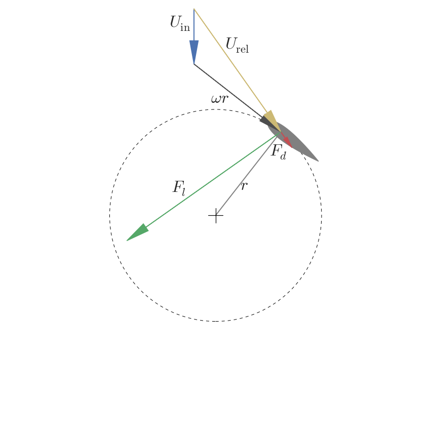

```python
import warnings
warnings.filterwarnings("ignore")
os.chdir(os.path.join(os.path.expanduser("~"), "Google Drive", "Research", "CFT-vectors"))
import cft_vectors
fig, ax = plt.subplots(figsize=(15, 15))
old_fontsize = plt.rcParams["font.size"]
plt.rcParams["font.size"] *= 1.5
cft_vectors.plot_diagram(fig, ax, theta_deg=52, axis="off", label=True)
os.chdir(talk_dir)
plt.rcParams["font.size"] = old_fontsize
```

## Kinematics

[video not shown]

## Marine hydrokinetics: ORPC

[figure not shown]

From orpc.co.

## Wind turbine arrays: Caltech FLOWE

[figure not shown]

From flowe.caltech.edu.

## Research objectives

1. Understand and predict wake recovery to open up array possibilities
2. Improve performance modeling
   - Progress in predicting unsteady separating flows

## Turbine test bed

Automated turbine testing in the UNH tow tank

[figure not shown]

## Test bed instrumentation

[figure not shown]

## Wake measurement instrumentation

- Nortek Vectrino+ acoustic Doppler velocimeter (ADV)
- $y$–$z$ traversing carriage
- Motion control integration

[figure not shown]

## Automation

[figure not shown]

## Operation

[video not shown]

## UNH-RVAT

[figure not shown]

- Simple geometry
- High solidity $(c/R)$
- Baseline experiments
- $U_\infty = 1$ m/s
- Characterize performance
- Understand wake dynamics
- Establish modeling "targets"

## UNH-RVAT baseline performance

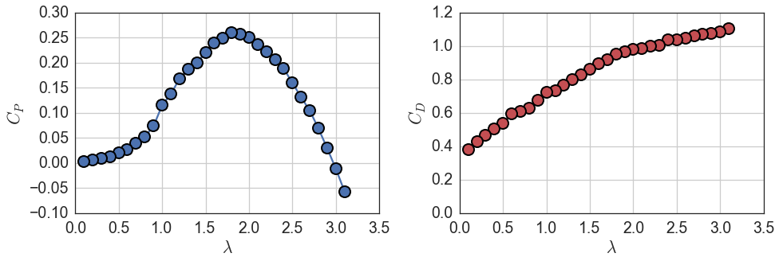

```python
# Generate figures from the experiments by their own methods

os.chdir("C:/Users/Pete/Research/Experiments/RVAT baseline")
import py_rvat_baseline.plotting as rvat_baseline

fig, (ax1, ax2) = plt.subplots(figsize=(14, 5), nrows=1, ncols=2)
rvat_baseline.plot_cp(ax1)
rvat_baseline.plot_cd(ax2, color=sns.color_palette()[2])
fig.tight_layout()
```

$\lambda = \frac{\omega R}{U_\infty}$ $C_P = \frac{P_\mathrm{mech}}{\frac{1}{2}\rho A_\mathrm{f} U_\infty^3}$ $C_D = \frac{F_\mathrm{drag}}{\frac{1}{2}\rho A_\mathrm{f} U_\infty^2}$

## Baseline wake measurements $(x/D=1)$

[figure not shown]

## UNH-RVAT baseline wake characteristics

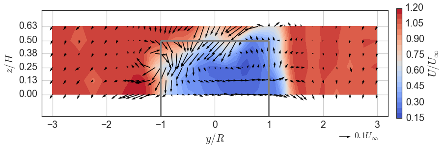

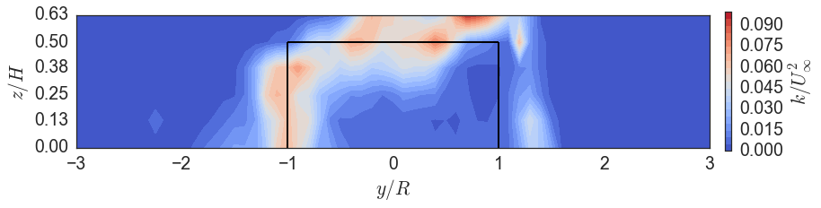

```python
os.chdir(rvat_baseline_dir)
rvat_baseline.plotwake("meancontquiv", scale=1.8)
rvat_baseline.plotwake("kcont", scale=1.8)
```

## Mean momentum transport

$$ \begin{split} \frac{\partial U}{\partial x} = \frac{1}{U} \bigg{[} & - V\frac{\partial U}{\partial y} - W\frac{\partial U}{\partial z} \\ & -\frac{1}{\rho}\frac{\partial P}{\partial x} \\ & - \frac{\partial}{\partial x} \overline{u'u'} - \frac{\partial}{\partial y} \overline{u'v'} - \frac{\partial}{\partial z} \overline{u'w'} \\ & + \nu\left(\frac{\partial^2 U}{\partial x^2} + \frac{\partial^2 U}{\partial y^2} + \frac{\partial^2 U}{\partial z^2} \right) \bigg{]}. \end{split} $$

## Mean momentum transport

Weighted averages at $x/D=1$:

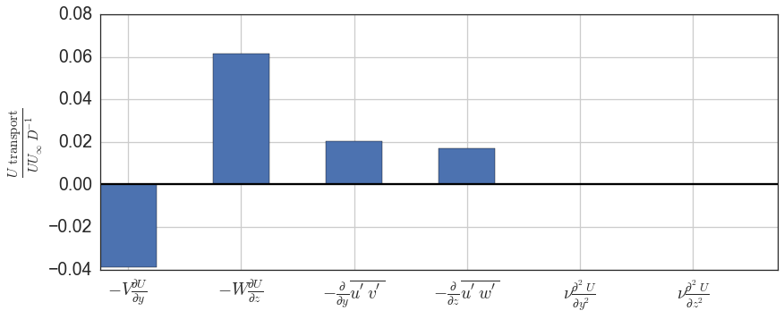

```python
os.chdir("C:/Users/Pete/Research/Experiments/RVAT baseline")
import py_rvat_baseline.plotting as rvat_baseline

rvat_baseline.plotwake("mombargraph", scale=1.8, barcolor=None)
plt.grid(True)
```

## UNH-RVAT Reynolds number dependence

- Are our results relevant to full scale?
- Models should be validated for the scales at which they will be applied, if possible
- How cheap (small, slow) can experiments get?

$$ Re = \frac{Ul}{\nu} $$

## UNH-RVAT Reynolds number dependence

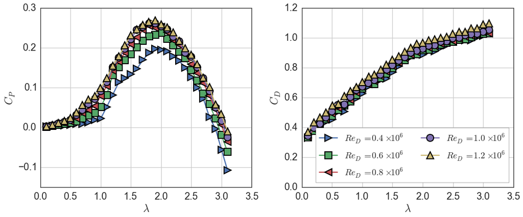

```python
os.chdir(rvat_re_dep_dir)
import py_rvat_re_dep.plotting as rvat_re_dep

fig, (ax1, ax2) = plt.subplots(figsize=(15, 6.5), nrows=1, ncols=2)
rvat_re_dep.plot_perf_curves(ax1, ax2)
fig.tight_layout()
```

## Reynolds number dependence at $\lambda = 1.9$

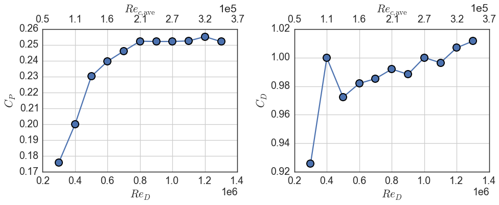

```python
os.chdir(rvat_re_dep_dir)
import py_rvat_re_dep.plotting as rvat_re_dep

fig, (ax1, ax2) = plt.subplots(figsize=(14, 6), nrows=1, ncols=2)
rvat_re_dep.plot_perf_re_dep(ax1, ax2)
fig.tight_layout()
```

## Blade boundary layer dynamics

[figure not shown]

From McMasters and Henderson (1980)

## Wake transport totals

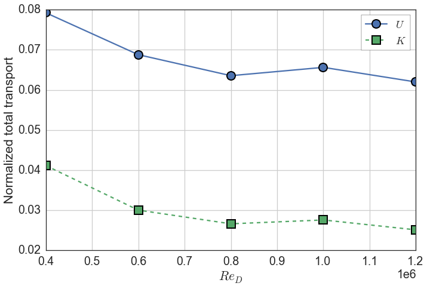

```python
os.chdir(rvat_re_dep_dir)
import py_rvat_re_dep.plotting as rvat_re_dep

fig, ax = plt.subplots()
rvat_re_dep.plot_wake_trans_totals(ax, emptymarkers=False, ucolor=sns.color_palette()[0],
                                   kcolor=sns.color_palette()[1])
fig.tight_layout()
```

## Numerical modeling

- Experiments are expensive
- Can be difficult to modify, e.g., turbine geometry
- Scaling issues
- Can we compute instead?

## Techniques

- **Blade element methods:** Use section characteristics to predict loading
  - Momentum: Very cheap, issues with high solidity, very little flow information
  - Vortex (potential flow): Cheap, also issues with high solidity, no turbulence
- **Navier–Stokes:** Turbulence modeled via RANS or LES (no DNS possible at this $Re$, yet)
  - Highest cost

## UNH-RVAT blade-resolved RANS

- Simulate baseline with OpenFOAM

[figure not shown]

- Need to resolve the boundary layer
- Separation
- Transition?
- Turbulence models (eddy viscosity)
- $k$–$\omega$ SST
- Spalart–Allmaras
- 2-D: $\sim 1$ CPU hour
- 3-D: $\sim 10^4$ CPU hours
- Feasible to replace experiments?
- "Interpolate" wake measurements?

## Overall mesh topology

[figure not shown]

## Near-wall blade mesh

[figure not shown]

$$ y^+ \sim 1 $$

## Verification (2-D)

[figure not shown]

## Performance predictions

[figure not shown]

## Near-wake mean velocity (SA 3-D vs. experiment)

[figure not shown]

## Near-wake mean velocity (SST 3-D vs. experiment)

[figure not shown]

## Near-wake TKE (SA 3-D vs. experiment)

[figure not shown]

## Near-wake TKE (SST 3-D vs. experiment)

[figure not shown]

## Near-wake momentum transport

[figure not shown]

## Summary: Blade-resolved CFD

- 2-D feasible but poor predictor of performance and wake
- 3-D *may* be good for single turbine, but too expensive for arrays

## Actuator line modeling

- Developed by Sorensen and Shen (2002)
- Blade element method coupled with Navier–Stokes
- Save computational resources
  - No finely resolved blade boundary layers
  - No complicated meshing
  - No mesh motion
- More physical description of wake evolution, turbulence
- Should resolve wakes of high solidity turbine blades

## Computing blade loading

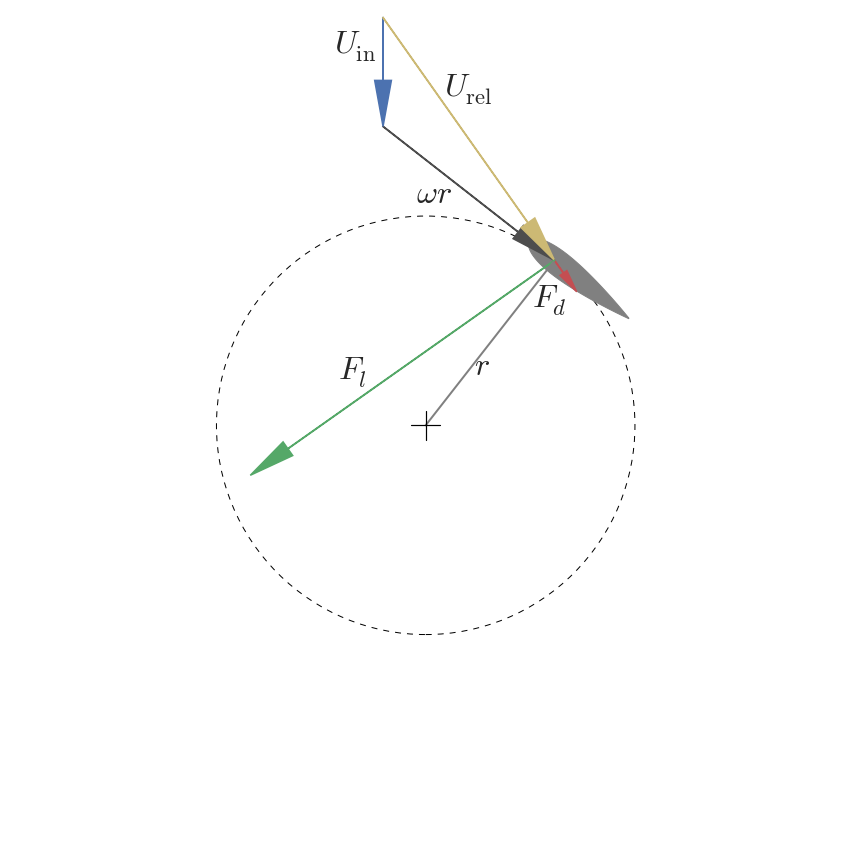

```python
import warnings
warnings.filterwarnings("ignore")
os.chdir(os.path.join(os.path.expanduser("~"), "Google Drive", "Research", "CFT-vectors"))
import cft_vectors
fig, ax = plt.subplots(figsize=(15, 15))
old_fontsize = plt.rcParams["font.size"]
plt.rcParams["font.size"] *= 1.5
cft_vectors.plot_diagram(fig, ax, theta_deg=52, axis="off", label=True)
os.chdir(talk_dir)
plt.rcParams["font.size"] = old_fontsize
```

## Flow field coupling

AL force added to Navier–Stokes as body force source term at element positions:

$$ \frac{\partial \vec{u}}{\partial t} + \vec{u} \cdot \nabla \vec{u} = -\frac{1}{\rho}\nabla p + \nabla^2 \vec{u} + \boxed{\vec{f}} $$

Force is smoothed outwards with a spherical Gaussian function to avoid numerical instability.

## Implementation

OpenFOAM extension library using `fvOptions` generic mechanism for adding sources at run time:

```
// Solve the Momentum equation

tmp<fvVectorMatrix> UEqn
(
    fvm::ddt(U)
  + fvm::div(phi, U)
  + turbulence->divDevReff(U)
 ==
    fvOptions(U)
);
```

Leverage existing solvers, parallelization, turbulence models. *No wheel reinvention.*

## UNH-RVAT actuator line simulation

- Preliminary validation
- Standard $k$–$\epsilon$ RANS model
- Similar domain and BCs as 3-D blade-resolved case
- Leishman–Beddoes DS model modified by Sheng et al. (2008)
- Flow curvature correction from Goude (2012)
- Ad hoc end effects model (full elliptical taper)

## UNH-RVAT actuator line simulation: Mesh

[figure not shown]

## Preliminary results: UNH-RVAT performance

[figure not shown]

## Near-wake mean velocity (ALM)

[figure not shown]

## Near-wake TKE (ALM vs. experiment)

[figure not shown]

## Conclusions

- ALM results are promising
  - Reduce computational effort by $\sim 10^4$ in 3-D RANS (not including meshing)
  - Performance predictions close to 3-D B-R RANS at optimal $\lambda$
  - Overprediction of $C_P$ at high $\lambda$
  - More flow information than momentum or vortex methods—better array modeling

## Issues to resolve

- Blade-vortex interaction
- End effects model
- Added mass
- Blade BL turbulence "injection" (calibration via 2-D RANS)

[figure not shown]

## Acknowledgements

[figure not shown]